# titanic

Chapter 1 - Define the Problem  
Chapter 2 - Gather the Data  
Chapter 3 - Exploratory Data Analysis  
Chapter 4 - Data Cleaning  
Chapter 5 - Model Data  
Chapter 6 - Submission

## **Chapter 1 - Define the Problem**

영화 '타이타닉' 한번 쯤 들어보셨나요?  
저는 어릴적 봤던영화인데 어린나이에도 참 감명깊게 봤었습니다.  
우리에겐 영화로써 널리 알려져 친숙한 사건인 RMS 타이타닉 침몰사건은 실제로 일어난 가장 유명한 여객선 침몰사건 사건 중 하나입니다.  
1912년 4월 15일 2224명의 승객을 태우고 1502명의 사상자를 낸 이 사건은 승객들을 위한 구명보트의 부족,  
차가운 물의 온도, 사후조치 미흡 등으로 더욱 많은 사람이 사망하게 되었다고 합니다.  
그 중, 약 700여명의 생존자들 중에는, 여성이나 아이, 상류층의 사람들이 더 많이 살아남았다고 합니다.

캐글에서 이를 데이터화 하여 학습을 진행해볼 수 있습니다.  
우리는 여기서 418개의 테스트데이터(testdata)와, 891개의 훈련데이터(traindata)를 사용하여  
어떠한 요인들이 생존률에 영향을 미쳤는지 알아보도록 하겠습니다.  
해당 competition의 description은 <a href = 'https://www.kaggle.com/c/titanic'> 여기를 클릭 </a> 해서 확인하실 수 있습니다.

### **Chapter 2 - Gather the Data**

분석에 필요한 데이터는 캐글로부터 주어져있습니다.  
데이터의 description은 <a href = 'https://www.kaggle.com/c/titanic/data'> 여기를 클릭 </a> 해서 확인하실 수 있습니다.

### **Chapter 2 - 1 - import Libraries**

```python
import pandas as pd
from pandas import Series
import numpy as np
import scipy as sp
import sklearn
import copy

#misc libraries
import random as rnd
import time

#ignore warnings
import warnings
warnings.filterwarnings('ignore')

#Common Model Algorithms
from sklearn import svm, tree, linear_model, neighbors, naive_bayes, ensemble, discriminant_analysis, gaussian_process

import xgboost as xgb
from xgboost import XGBClassifier

#Common Model Helpers
from sklearn.preprocessing import OneHotEncoder, LabelEncoder
from sklearn import feature_selection
from sklearn import model_selection
from sklearn.model_selection import train_test_split
from sklearn import metrics
from sklearn.metrics import mean_squared_error
from sklearn.model_selection import KFold


#Visualization
import matplotlib as mpl
import matplotlib.pyplot as plt
import matplotlib.pylab as pylab
import seaborn as sns
from pandas.tools.plotting import scatter_matrix
import missingno as msno

#Configure Visualization Defaults
%matplotlib inline
mpl.style.use('seaborn')
```

### **Chapter 2 - 2 - Check data set**

분석을 시작하기에 앞서 데이터를 이해하는 것이 가장 중요합니다.  
pandas 라이브러리를 사용하여 주어진 데이터를 읽어온 후, 데이터를 살펴보도록 하겠습니다.

```python
#df_train = pd.read_csv('../input/train.csv')
#df_test = pd.read_csv('../input/test.csv')

df_train = pd.read_csv('C:/Users/hongo/OneDrive/BIGDATA/kaggle/titanic/train.csv')
df_test = pd.read_csv('C:/Users/hongo/OneDrive/BIGDATA/kaggle/titanic/test.csv')

df_all = pd.concat([df_train, df_test])
```

```python
df_train.head()
```

|  | PassengerId | Survived | Pclass | Name | Sex | Age | SibSp | Parch | Ticket | Fare | Cabin | Embarked |
| --- | --- | --- | --- | --- | --- | --- | --- | --- | --- | --- | --- | --- |
| 0 | 1 | 0 | 3 | Braund, Mr. Owen Harris | male | 22.0 | 1 | 0 | A/5 21171 | 7.2500 | NaN | S |
| 1 | 2 | 1 | 1 | Cumings, Mrs. John Bradley (Florence Briggs Th... | female | 38.0 | 1 | 0 | PC 17599 | 71.2833 | C85 | C |
| 2 | 3 | 1 | 3 | Heikkinen, Miss. Laina | female | 26.0 | 0 | 0 | STON/O2. 3101282 | 7.9250 | NaN | S |
| 3 | 4 | 1 | 1 | Futrelle, Mrs. Jacques Heath (Lily May Peel) | female | 35.0 | 1 | 0 | 113803 | 53.1000 | C123 | S |
| 4 | 5 | 0 | 3 | Allen, Mr. William Henry | male | 35.0 | 0 | 0 | 373450 | 8.0500 | NaN | S |

```python
df_train.describe(include='all')
```

|  | PassengerId | Survived | Pclass | Name | Sex | Age | SibSp | Parch | Ticket | Fare | Cabin | Embarked |
| --- | --- | --- | --- | --- | --- | --- | --- | --- | --- | --- | --- | --- |
| count | 891.000000 | 891.000000 | 891.000000 | 891 | 891 | 714.000000 | 891.000000 | 891.000000 | 891 | 891.000000 | 204 | 889 |
| unique | NaN | NaN | NaN | 891 | 2 | NaN | NaN | NaN | 681 | NaN | 147 | 3 |
| top | NaN | NaN | NaN | Carter, Miss. Lucile Polk | male | NaN | NaN | NaN | 347082 | NaN | G6 | S |
| freq | NaN | NaN | NaN | 1 | 577 | NaN | NaN | NaN | 7 | NaN | 4 | 644 |
| mean | 446.000000 | 0.383838 | 2.308642 | NaN | NaN | 29.699118 | 0.523008 | 0.381594 | NaN | 32.204208 | NaN | NaN |
| std | 257.353842 | 0.486592 | 0.836071 | NaN | NaN | 14.526497 | 1.102743 | 0.806057 | NaN | 49.693429 | NaN | NaN |
| min | 1.000000 | 0.000000 | 1.000000 | NaN | NaN | 0.420000 | 0.000000 | 0.000000 | NaN | 0.000000 | NaN | NaN |
| 25% | 223.500000 | 0.000000 | 2.000000 | NaN | NaN | 20.125000 | 0.000000 | 0.000000 | NaN | 7.910400 | NaN | NaN |
| 50% | 446.000000 | 0.000000 | 3.000000 | NaN | NaN | 28.000000 | 0.000000 | 0.000000 | NaN | 14.454200 | NaN | NaN |
| 75% | 668.500000 | 1.000000 | 3.000000 | NaN | NaN | 38.000000 | 1.000000 | 0.000000 | NaN | 31.000000 | NaN | NaN |
| max | 891.000000 | 1.000000 | 3.000000 | NaN | NaN | 80.000000 | 8.000000 | 6.000000 | NaN | 512.329200 | NaN | NaN |

### **Chapter 2 - 3 - Check Null Data**

null값은 예측모델에 굉장히 부정적인 영향을 주므로, 반드시 조치를 취해아합니다.  
따라서 데이터를 체크할 때, 결측값을 반드시 확인해보도록 합니다.

아래와같이 Age, Cabin, Embarked(train), Fare(test) 컬럼에 null 값이 있다는 것을 확인할 수 있으며,  
구체적인 분포와 양을 정량화, 시각화 시켜서 알아볼 수 있습니다.

```python
for col in df_train.columns:
    print('col : {:<10} \t count : {:<5} \t Null count : {:<5}  Percent of Null value : {:.2f}%'.format(col,df_train[col].shape[0], df_train[col].isnull().sum(), df_train[col].isnull().sum()/df_train[col].shape[0]*100))
```

```
col : PassengerId 	 count : 891   	 Null count : 0      Percent of Null value : 0.00%
col : Survived   	 count : 891   	 Null count : 0      Percent of Null value : 0.00%
col : Pclass     	 count : 891   	 Null count : 0      Percent of Null value : 0.00%
col : Name       	 count : 891   	 Null count : 0      Percent of Null value : 0.00%
col : Sex        	 count : 891   	 Null count : 0      Percent of Null value : 0.00%
col : Age        	 count : 891   	 Null count : 177    Percent of Null value : 19.87%
col : SibSp      	 count : 891   	 Null count : 0      Percent of Null value : 0.00%
col : Parch      	 count : 891   	 Null count : 0      Percent of Null value : 0.00%
col : Ticket     	 count : 891   	 Null count : 0      Percent of Null value : 0.00%
col : Fare       	 count : 891   	 Null count : 0      Percent of Null value : 0.00%
col : Cabin      	 count : 891   	 Null count : 687    Percent of Null value : 77.10%
col : Embarked   	 count : 891   	 Null count : 2      Percent of Null value : 0.22%
```

```python
for col in df_test.columns:
    print('col : {:<10} \t count : {:<5} \t Null count : {:<5}  Percent of Null value : {:.2f}%'.format(col,df_test[col].shape[0], df_test[col].isnull().sum(), df_test[col].isnull().sum()/df_test[col].shape[0]*100))
```

```
col : PassengerId 	 count : 418   	 Null count : 0      Percent of Null value : 0.00%
col : Pclass     	 count : 418   	 Null count : 0      Percent of Null value : 0.00%
col : Name       	 count : 418   	 Null count : 0      Percent of Null value : 0.00%
col : Sex        	 count : 418   	 Null count : 0      Percent of Null value : 0.00%
col : Age        	 count : 418   	 Null count : 86     Percent of Null value : 20.57%
col : SibSp      	 count : 418   	 Null count : 0      Percent of Null value : 0.00%
col : Parch      	 count : 418   	 Null count : 0      Percent of Null value : 0.00%
col : Ticket     	 count : 418   	 Null count : 0      Percent of Null value : 0.00%
col : Fare       	 count : 418   	 Null count : 1      Percent of Null value : 0.24%
col : Cabin      	 count : 418   	 Null count : 327    Percent of Null value : 78.23%
col : Embarked   	 count : 418   	 Null count : 0      Percent of Null value : 0.00%
```

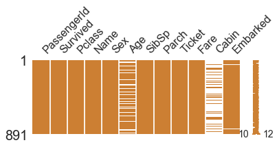

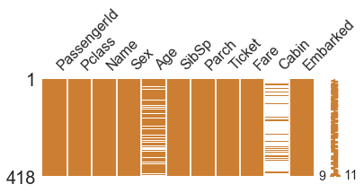

```python
msno.matrix(df = df_train, figsize = (6,2), color=(0.8, 0.5, 0.2))
msno.matrix(df = df_test, figsize = (6,2), color=(0.8, 0.5, 0.2))
```

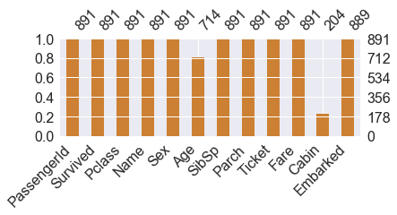

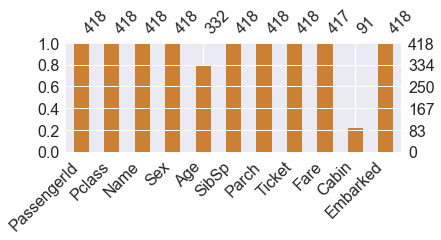

```python
msno.bar(df = df_train, figsize = (6,2), color=(0.8, 0.5, 0.2))
msno.bar(df = df_test, figsize = (6,2), color=(0.8, 0.5, 0.2))
```

## **Chapter 3 - Exploratory Data Analysis**

EDA란, 탐색적 데이터 분석기법 이라고합니다.  
우리가 가지고있는 데이터의 형태와 특징들, 그리고 각각의 변인들과 타겟레이블과의 관계를 시각화하여 알아보겠습니다.

```python
for cnt,i in enumerate(df_train.columns) :
    print('### **'+str(cnt+1),'-',i.upper()+'**')
```

### **1 - Survived**

우리의 타겟레이블 입니다.  
생존은 1로, 사망은 0 으로 표기되어있습니다 우선 타겟레이블을 살펴본 후, 다음 변수들부터는 타겟레이블과 각 변인들간의 관계를 알아보겠습니다.  
생존은 342명, 사망이 549명으로 안타깝게도 사망자 수가 더 많네요.  
비율은 6:4 정도로, 한쪽으로 많이 치우쳐져있지 않은 준수한 비율을 보이고 있습니다.

```python
df_train['Survived'].value_counts()
```

```
0    549
1    342
Name: Survived, dtype: int64
```

```
[Text(0,0,'0'), Text(0,0,'1')]
```

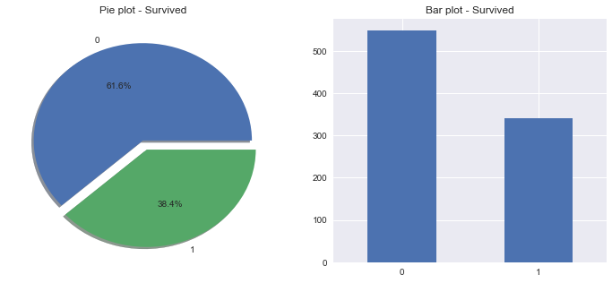

```python
f, ax = plt.subplots(1,2, figsize=(12,5))

df_train['Survived'].value_counts().plot.pie(explode = [0,0.1], autopct = '%1.1f%%', ax=ax[0], shadow = True)
ax[0].set_title('Pie plot - Survived')
ax[0].set_ylabel('')

df_train['Survived'].value_counts().plot.bar(ax=ax[1])
ax[1].set_title('Bar plot - Survived')
ax[1].set_xticklabels(df_train['Survived'], rotation=0)
```

### **2 - Pclass**

Pclass값은 1,2,3으로 구성되어있는데, 1=1등급, 2=2등급, 3=3등급을 나타냅니다.  
높은등급에 탑승했을수록 생존율이 높음을 알 수 있습니다.

```python
df_train[['Pclass','Survived']].groupby('Pclass', as_index=False).mean().sort_values(by='Survived', ascending=False)
```

|  | Pclass | Survived |
| --- | --- | --- |
| 0 | 1 | 0.629630 |
| 1 | 2 | 0.472826 |
| 2 | 3 | 0.242363 |

```python
pd.crosstab(df_train['Pclass'],df_train['Survived'],margins=True).style.background_gradient(cmap='summer_r')
```

| Survived Pclass | 0 | 1 | All |
| --- | --- | --- | --- |
| 1 | 80 | 136 | 216 |
| 2 | 97 | 87 | 184 |
| 3 | 372 | 119 | 491 |
| All | 549 | 342 | 891 |

[figure not shown]

```python
f,ax = plt.subplots( 1,2, figsize = (12,5) )

df_train['Pclass'].value_counts().plot.bar(ax=ax[0])
ax[0].set_xticklabels(df_train['Pclass'], rotation=0)
ax[0].set_title('Number of passengers')
ax[0].set_xlabel('Pclass')

sns.countplot('Pclass', hue='Survived', data=df_train, ax=ax[1])
ax[1].set_title('Survived ratio')

plt.subplots_adjust(wspace=0.5)
```

### **2 - Name**

이름은 온전한 고유값이므로, 이름 자체에서는 생존률과 연관된 직접적인 insight를 얻기 힘들 것으로 생각됩니다.  
일단은 넘어가고 데이터 클렌징 작업을 진행하면서 이곳에서 얻을 수 있는 정보가 있는지 재 탐색 하겠습니다.

### **3 - Sex**

성별값은 남성 = male, 여성 = female 로 구분되어있습니다.  
성별의 경우, 여성의 생존률이 남성의 생존률 보다 월등히 높다는 것이 확인됩니다.

```python
df_train['Sex'].value_counts()
```

```
male      577
female    314
Name: Sex, dtype: int64
```

```python
df_train[['Sex','Survived']].groupby('Sex', as_index=False).mean().sort_values('Survived', ascending=False)
```

|  | Sex | Survived |
| --- | --- | --- |
| 0 | female | 0.742038 |
| 1 | male | 0.188908 |

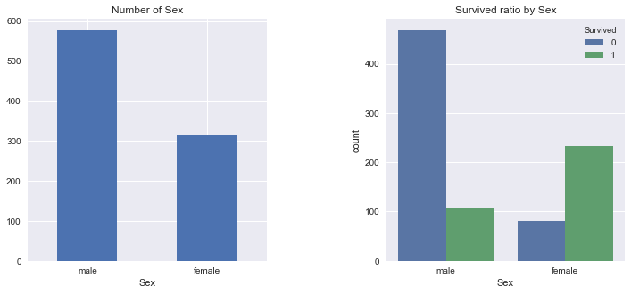

```python
f, ax = plt.subplots(1,2,figsize=(12,5))

df_train['Sex'].value_counts().plot.bar(ax=ax[0])
ax[0].set_xticklabels(df_train['Sex'], rotation=0)
ax[0].set_title('Number of Sex')
ax[0].set_xlabel('Sex')

sns.countplot('Sex', hue = 'Survived', data=df_train, ax=ax[1])
ax[1].set_title('Survived ratio by Sex')

plt.subplots_adjust(wspace = 0.5)
```

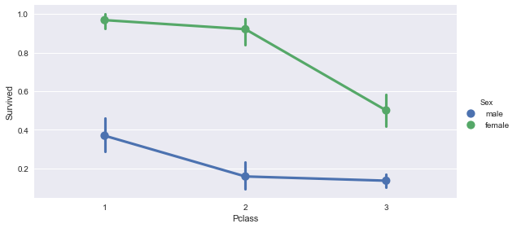

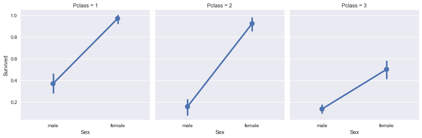

```python
sns.catplot(x='Pclass', y='Survived', hue = 'Sex', data=df_train, kind='point', height=4, aspect=2)

sns.catplot(x='Sex', y='Survived', col='Pclass', data=df_train, kind='point', height=4, aspect=1)
```

### **4 - Age**

Age 데이터를 살펴보겠습니다.

```python
print('Age of The oldest passengers  : {}'.format(df_train['Age'].max()))
print('Age of The least oldest passengers : {}'.format(df_train['Age'].min()))
print('Average age of passengers : {:.2f}'.format(df_train['Age'].mean()))
```

```
Age of The oldest passengers  : 80.0
Age of The least oldest passengers : 0.42
Average age of passengers : 29.70
```

```
Text(0.5,1,'Distribution by Age')
```

[figure not shown]

```python
f, ax = plt.subplots(1,1,figsize=(10,4))

sns.kdeplot(df_train[df_train['Survived']==0]['Age'], shade=True, ax=ax)
sns.kdeplot(df_train[df_train['Survived']==1]['Age'], shade=True, ax=ax)
plt.legend(['Survived=1','Survived=0'])
ax.set_title('Distribution by Age')
```

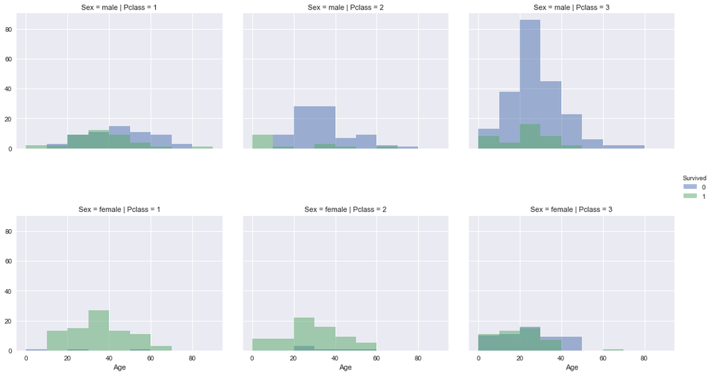

```python
bins = np.arange(0, 100, 10)
h = sns.FacetGrid(df_train, row = 'Sex', col = 'Pclass', hue = 'Survived', size=4, aspect=1.2)
h.map(plt.hist, 'Age', bins=bins, alpha=.5).add_legend()
h.fig.subplots_adjust(hspace=0.5, wspace=0.1)
```

### **5 - Family (SibSp + Parch)**

Family feature를 살펴보겠습니다.  
Family는 SibSp와 Parch을 모두 합쳐 가족구성원의 의미로 만든 feature입니다.

```python
df_train['Family'] = df_train['SibSp']+df_train['Parch']+1
df_test['Family'] = df_test['SibSp']+df_test['Parch']+1
```

```python
print('Maximum size of Family : ', df_train['Family'].max())
print('Minimum size of Family : ', df_train['Family'].min())
```

```
Maximum size of Family :  11
Minimum size of Family :  1
```

```python
df_train.head()
```

|  | PassengerId | Survived | Pclass | Name | Sex | Age | SibSp | Parch | Ticket | Fare | Cabin | Embarked | Family |
| --- | --- | --- | --- | --- | --- | --- | --- | --- | --- | --- | --- | --- | --- |
| 0 | 1 | 0 | 3 | Braund, Mr. Owen Harris | male | 22.0 | 1 | 0 | A/5 21171 | 7.2500 | NaN | S | 2 |
| 1 | 2 | 1 | 1 | Cumings, Mrs. John Bradley (Florence Briggs Th... | female | 38.0 | 1 | 0 | PC 17599 | 71.2833 | C85 | C | 2 |
| 2 | 3 | 1 | 3 | Heikkinen, Miss. Laina | female | 26.0 | 0 | 0 | STON/O2. 3101282 | 7.9250 | NaN | S | 1 |
| 3 | 4 | 1 | 1 | Futrelle, Mrs. Jacques Heath (Lily May Peel) | female | 35.0 | 1 | 0 | 113803 | 53.1000 | C123 | S | 2 |
| 4 | 5 | 0 | 3 | Allen, Mr. William Henry | male | 35.0 | 0 | 0 | 373450 | 8.0500 | NaN | S | 1 |

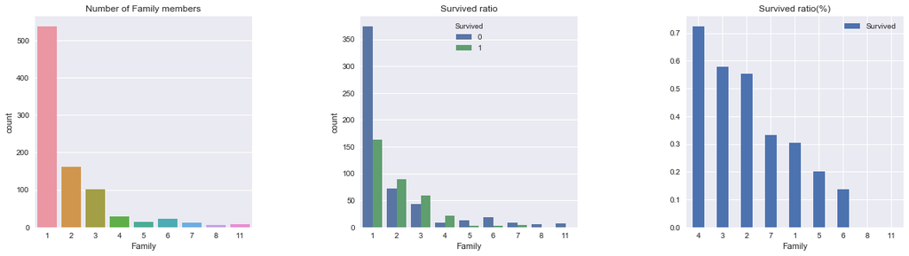

```python
f, ax = plt.subplots(1,3,figsize=(20,5))

sns.countplot('Family', data=df_train, ax=ax[0])
ax[0].set_title('Number of Family members')

sns.countplot('Family',hue='Survived',data=df_train,ax=ax[1])
ax[1].set_title('Survived ratio')

df_train[['Family','Survived']].groupby('Family').mean().sort_values(by='Survived',ascending=False).plot.bar(ax=ax[2])
ax[2].tick_params(axis='both', which='both', labelbottom=True, rotation = 0)
ax[2].set_title('Survived ratio(%)')
plt.subplots_adjust(wspace=0.5)
```

### **6 - Ticket**

티켓부분은 랜덤하게 얻어지며 고유값이 굉장히 높은 데이터입니다.  
해당 데이터 역시 넘어가도록 하겠습니다.

### **7 - Fare**

해당 데이터는 고객의 탑승요금을 나타내는 지표입니다.  
낮은 구매금액대에서 사망자가 많은것으로 보여집니다.

```python
df_train[['Fare','Pclass']].corr()
```

|  | Fare | Pclass |
| --- | --- | --- |
| Fare | 1.0000 | -0.5495 |
| Pclass | -0.5495 | 1.0000 |

```
Text(0.5,1,'Survived ratio by Fare')
```

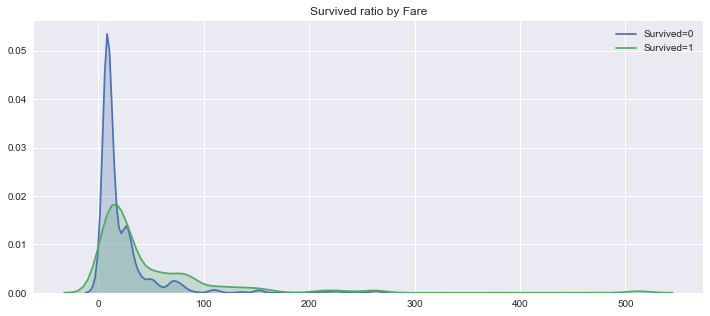

```python
f, ax = plt.subplots(1,1,figsize=(12,5))

sns.kdeplot(df_train['Fare'][df_train['Survived']==0], shade = True, ax=ax)
sns.kdeplot(df_train['Fare'][df_train['Survived']==1], shade = True, ax=ax)

plt.legend(['Survived=0','Survived=1'])
ax.set_title('Survived ratio by Fare')
```

### **8 - Cabin**

Cabin은 탑승객의 캐비넷 정보가 담겨있는데, 사고시점에 탑승객이 캐비넷에 있었다면  
캐비넷 위치에따라 고객의 생존률에 영향을 주었을 지도 모릅니다.  
하지만 현재 결측값이 너무 많은상태이기 때문에 이번 Cabin의 데이터는 분석하지 않도록 하겠습니다.

### **9 - Embarked**

Embarked는 탑승객이 어디서 탑승했는지의 정보이며  
C = Cherbourg, Q = Queenstown, S = Southampton 3가지로 나뉘어집니다.

```python
df_train['Embarked'].value_counts()
```

```
S    644
C    168
Q     77
Name: Embarked, dtype: int64
```

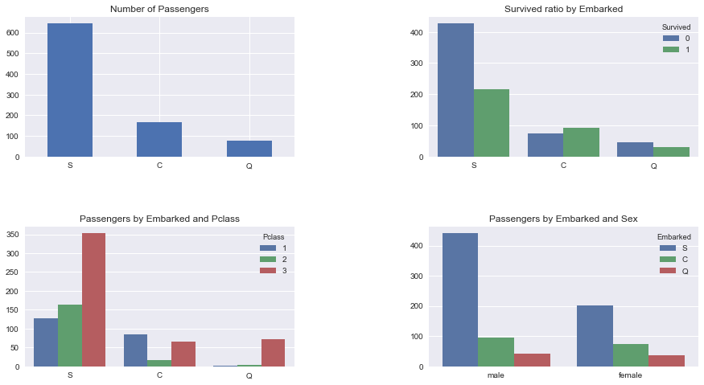

```python
f, ax = plt.subplots(2,2,figsize=(15,8))

df_train['Embarked'].value_counts().plot.bar(ax=ax[0,0])
ax[0,0].tick_params(axis='both', which='both', rotation=0)
ax[0,0].set_title('Number of Passengers')

sns.countplot('Embarked',hue = 'Survived', data = df_train, ax=ax[0,1])
ax[0,1].set_title('Survived ratio by Embarked')
ax[0,1].set_ylabel('')
ax[0,1].set_xlabel('')
ax[0,1].tick_params(axis='both', which='both', rotation=0)

sns.countplot('Embarked', hue='Pclass',data=df_train,  ax=ax[1,0])
ax[1,0].set_title('Passengers by Embarked and Pclass')
ax[1,0].set_xlabel('')
ax[1,0].set_ylabel('')

sns.countplot('Sex', hue='Embarked', data=df_train, ax=ax[1,1])
ax[1,1].set_title('Passengers by Embarked and Sex')
ax[1,1].set_xlabel('')
ax[1,1].set_ylabel('')

plt.subplots_adjust(wspace=0.5, hspace = 0.5)
```

### **10 - EDA 마무리**

```python
def corrsort(targetindexname) :
    targetindex = df_train.columns.get_loc(targetindexname)
    corrtarget = df_train.corr().loc[:,targetindexname]
    corrtargetsort = 'corrtarget.reindex(corrtarget.abs().sort_values(ascending=False).index)'
    print(eval(corrtargetsort))
    print('--'*20)
#    for i in eval(corrtargetsort).index.tolist() :
#        print(i+',')
```

```python
corrsort('Survived')
```

```
Survived       1.000000
Pclass        -0.338481
Fare           0.257307
Parch          0.081629
Age           -0.077221
SibSp         -0.035322
Family         0.016639
PassengerId   -0.005007
Name: Survived, dtype: float64
----------------------------------------
```

## **Chapter 4 - Data Cleaning**

일반적으로 데이터 클리닝에는 아래와 같이 4가지 방법이 있습니다.

1. Correcting: 데이터를 리뷰하면서, 범주에 벗어난 듯 보이는 데이터를 식별하여 바로잡습니다. (i.e. Age 값이 800인 경우 800살이 실제로 가능하지 않으므로 비 정상데이터로 간주)
2. Completing: 데이터의 결측값을 채워줍니다. 통상적으로는, null값이 포함된 row 자체를 지워버리는 방법과, 각 feature의 특성이 반영된 대체값으로 대체하는 방법이 있습니다.  
   데이터를 지워버리는 방법보다는 최대값, 중간값, 평균값 등으로 대체하는 것을 추천합니다.
3. Creating: 기존 feature로부터 새로운 feature를 만들어냅니다.
4. Converting: 데이터 타입을 바꿔줍니다. (i.e. 남자 = 1, 여자 = 2 로 변환)  
   기본적으로, 숫자를 다루는 알고리즘이기 때문에 문자열 데이터는 연산에 굉장히 불리하기때문에 데이터 타입을 전부 숫자로 바꿔줄 필요가 있습니다.

```python
#temp_df_train = copy.deepcopy(df_train)
#temp_df_test = copy.deepcopy(df_test)

#df_train = copy.deepcopy(temp_df_train)
#df_test = copy.deepcopy(temp_df_test)
```

### **Chapter 4 - 1 - Correcting**

위에서 살펴봤었지만, 이번 데이터에는 정상 범주를 벗어난 데이터는 없어보이므로 넘어가도록 하겠습니다.

### **Chapter 4 - 2 - Completing**

우선 null 값을 채우기 전, Cabin과 Ticket, Passengerid는 대상 feature에서 제외하도록 하겠습니다.  
우선 PassengerId와 Ticket은 고객별로 랜덤하게, 그리고 고유하게 특별한 의미가 없이 부여받는 번호이기 때문에  
여기서 생존과의 의미를 가지기 어렵고, Cabin의 경우에는 사고시점에 캐비넷에 있었던 고객이라면  
캐비넷의 위치에따라 구조위치와 가까운지 등이 생존률에 영향을 줄 수 있었을지도 모르지만  
결측값이 너무 많아 값을 채우기 어렵다고 판단했습니다.

결측치를 채워넣겠습니다.  
여기서 결측치를 채워넣는 방법에는 평균값, 중앙값, 최빈값 등 다양한 기준이 올 수 있습니다.  
Age와 Fare에는 중앙값을, Embarked에는 최빈값을 사용하여 데이터를 채우도록 하겠습니다.

중앙값과, 최빈값은, 트레인데이터와 테스트데이터를 모두 합친 중앙값과 최빈값을 사용하도록 합니다. (cabin은 사용하지 않을 예정으로 결측치를 채워넣지 않겠습니다.)

```python
df_train['Age'].fillna(df_all['Age'].median(), inplace = True)
df_test['Age'].fillna(df_all['Age'].median(), inplace = True)

df_train['Embarked'].fillna(df_all['Embarked'].mode()[0], inplace = True)
df_test['Embarked'].fillna(df_all['Embarked'].mode()[0], inplace = True)

df_train['Fare'].fillna(df_all['Fare'].median(), inplace = True)
df_test['Fare'].fillna(df_all['Fare'].median(), inplace = True)
```

```python
for col in df_train.columns:
    print('col : {:<10} \t count : {:<5} \t Null count : {:<5}  Percent of Null value : {:.2f}%'.format(col,df_train[col].shape[0], df_train[col].isnull().sum(), df_train[col].isnull().sum()/df_train[col].shape[0]*100))
```

```
col : PassengerId 	 count : 891   	 Null count : 0      Percent of Null value : 0.00%
col : Survived   	 count : 891   	 Null count : 0      Percent of Null value : 0.00%
col : Pclass     	 count : 891   	 Null count : 0      Percent of Null value : 0.00%
col : Name       	 count : 891   	 Null count : 0      Percent of Null value : 0.00%
col : Sex        	 count : 891   	 Null count : 0      Percent of Null value : 0.00%
col : Age        	 count : 891   	 Null count : 0      Percent of Null value : 0.00%
col : SibSp      	 count : 891   	 Null count : 0      Percent of Null value : 0.00%
col : Parch      	 count : 891   	 Null count : 0      Percent of Null value : 0.00%
col : Ticket     	 count : 891   	 Null count : 0      Percent of Null value : 0.00%
col : Fare       	 count : 891   	 Null count : 0      Percent of Null value : 0.00%
col : Cabin      	 count : 891   	 Null count : 687    Percent of Null value : 77.10%
col : Embarked   	 count : 891   	 Null count : 0      Percent of Null value : 0.00%
col : Family     	 count : 891   	 Null count : 0      Percent of Null value : 0.00%
```

```python
for col in df_test.columns:
    print('col : {:<10} \t count : {:<5} \t Null count : {:<5}  Percent of Null value : {:.2f}%'.format(col,df_test[col].shape[0], df_test[col].isnull().sum(), df_test[col].isnull().sum()/df_test[col].shape[0]*100))
```

```
col : PassengerId 	 count : 418   	 Null count : 0      Percent of Null value : 0.00%
col : Pclass     	 count : 418   	 Null count : 0      Percent of Null value : 0.00%
col : Name       	 count : 418   	 Null count : 0      Percent of Null value : 0.00%
col : Sex        	 count : 418   	 Null count : 0      Percent of Null value : 0.00%
col : Age        	 count : 418   	 Null count : 0      Percent of Null value : 0.00%
col : SibSp      	 count : 418   	 Null count : 0      Percent of Null value : 0.00%
col : Parch      	 count : 418   	 Null count : 0      Percent of Null value : 0.00%
col : Ticket     	 count : 418   	 Null count : 0      Percent of Null value : 0.00%
col : Fare       	 count : 418   	 Null count : 0      Percent of Null value : 0.00%
col : Cabin      	 count : 418   	 Null count : 327    Percent of Null value : 78.23%
col : Embarked   	 count : 418   	 Null count : 0      Percent of Null value : 0.00%
col : Family     	 count : 418   	 Null count : 0      Percent of Null value : 0.00%
```

### **Chapter 4 - 3 - Creating**

기존의 feature로부터, 새로운 feature를 발견해낼 수 있습니다.  
이전에 SibSp, Parch를 합쳐서 만들었던 Family가 그러한 것입니다.

그 외에 Name에서 유의미 할 수 있는 정보인 이름의 수식어(i.e. Mr, Mrs..)만을 뽑아온 Title,  
그리고 Age 데이터에서 나이대(16세 단위로 5개 그룹)의 AgeBin Fare데이터를 4개그룹으로 나눈 FareBin으로 만들어 보겠습니다.

```python
df_train['AgeBin']  = pd.cut(df_train['Age'].astype(int), 5)
df_test['AgeBin']  = pd.cut(df_test['Age'].astype(int), 5)

df_train['FareBin'] = pd.qcut(df_train['Fare'], 4)
df_test['FareBin'] = pd.qcut(df_test['Fare'], 4)

df_train['Title'] = df_train.Name.str.extract('([A-Za-z]+)\.')
df_test['Title'] = df_test.Name.str.extract('([A-Za-z]+)\.')

df_all['Title'] = df_all.Name.str.extract('([A-Za-z]+)\.')
stat_min = 10
title_names = (df_all['Title'].value_counts() < stat_min)
df_train['Title'] = df_train['Title'].apply(lambda x: 'Misc' if title_names.loc[x] == True else x)
df_test['Title'] = df_test['Title'].apply(lambda x: 'Misc' if title_names.loc[x] == True else x)
```

### **Chapter 4 - 4 - Convert**

데이터 타입을 숫자형태로 바꿔주는 작업입니다.

통상적으로 두 가지 방법이 많이 이용되는데요.  
첫 번째는 one-hot encoding이라는 기법입니다.  
범주형 변수에 많이 이용되는데요 각 컬럼의 unique한 값들로 컬럼을 하나씩 별도로 생성해서, 해당값이면 1 아니면 0 으로 나누는겁니다.  
예를들면 Embarked 컬럼에는 S, Q, C 3개의 값이 있었죠?  
그럼 Embarked_S, Embarked_Q, Embarked_C 라는 3개의 컬럼으로 각각 쪼개준 뒤,  
Embarked_S에는 Embarked값이 S이면 1 아니면 전부 0  
Embarked_Q에는 Embarked값이 Q이면 1 아니면 전부 0  
Embarked_C에는 Embarked값이 C이면 1 아니면 전부 0 의 값을 넣어주는 겁니다.  
판다스에서는 get_dummies라는 함수를 제공하여 이러한 작업을 손쉽게 할 수 있습니다.

두 번째 방법은 LabelEncoder 함수를 사용합니다.  
one-hot encoding과는 다르게, 별도의 컬럼을 생성하지않고, 증감식으로 0부터 1,2,3... 으로 나타냅니다.  
연속형 변수에 많이 사용되는데 나이그룹에 비유해보자면  
10대는 1  
20대는 2  
30대는 3  
이렇게 변경해주는거죠.

```python
df_train = pd.get_dummies(df_train, columns=['Title'], prefix='Title')
df_test = pd.get_dummies(df_test, columns=['Title'], prefix='Title')

df_train = pd.get_dummies(df_train, columns=['Embarked'], prefix='Embarked')
df_test = pd.get_dummies(df_test, columns=['Embarked'], prefix='Embarked')

df_train = pd.get_dummies(df_train, columns=['Sex'], prefix='Sex')
df_test = pd.get_dummies(df_test, columns=['Sex'], prefix='Sex')
```

```python
label = LabelEncoder()

df_train['AgeBin'] = label.fit_transform(df_train['AgeBin'])
df_test['AgeBin'] = label.fit_transform(df_test['AgeBin'])

df_train['FareBin'] = label.fit_transform(df_train['FareBin'])
df_test['FareBin'] = label.fit_transform(df_test['FareBin'])
```

```python
df_train.head()
```

|  | PassengerId | Survived | Pclass | Name | Age | SibSp | Parch | Ticket | Fare | Cabin | ... | Title_Master | Title_Misc | Title_Miss | Title_Mr | Title_Mrs | Embarked_C | Embarked_Q | Embarked_S | Sex_female | Sex_male |
| --- | --- | --- | --- | --- | --- | --- | --- | --- | --- | --- | --- | --- | --- | --- | --- | --- | --- | --- | --- | --- | --- |
| 0 | 1 | 0 | 3 | Braund, Mr. Owen Harris | 22.0 | 1 | 0 | A/5 21171 | 7.2500 | NaN | ... | 0 | 0 | 0 | 1 | 0 | 0 | 0 | 1 | 0 | 1 |
| 1 | 2 | 1 | 1 | Cumings, Mrs. John Bradley (Florence Briggs Th... | 38.0 | 1 | 0 | PC 17599 | 71.2833 | C85 | ... | 0 | 0 | 0 | 0 | 1 | 1 | 0 | 0 | 1 | 0 |
| 2 | 3 | 1 | 3 | Heikkinen, Miss. Laina | 26.0 | 0 | 0 | STON/O2. 3101282 | 7.9250 | NaN | ... | 0 | 0 | 1 | 0 | 0 | 0 | 0 | 1 | 1 | 0 |
| 3 | 4 | 1 | 1 | Futrelle, Mrs. Jacques Heath (Lily May Peel) | 35.0 | 1 | 0 | 113803 | 53.1000 | C123 | ... | 0 | 0 | 0 | 0 | 1 | 0 | 0 | 1 | 1 | 0 |
| 4 | 5 | 0 | 3 | Allen, Mr. William Henry | 35.0 | 0 | 0 | 373450 | 8.0500 | NaN | ... | 0 | 0 | 0 | 1 | 0 | 0 | 0 | 1 | 0 | 1 |

5 rows × 23 columns

### **Chapter 4 - 5 - Drop Column & Check data sets**

머신러닝 도입 전, 사용하지 않을 컬럼들을 정리하고, 피어슨상관계수를 통해 데이터를 다시 한 번 살펴보겠습니다.

```python
df_train.head()
```

|  | PassengerId | Survived | Pclass | Name | Age | SibSp | Parch | Ticket | Fare | Cabin | ... | Title_Master | Title_Misc | Title_Miss | Title_Mr | Title_Mrs | Embarked_C | Embarked_Q | Embarked_S | Sex_female | Sex_male |
| --- | --- | --- | --- | --- | --- | --- | --- | --- | --- | --- | --- | --- | --- | --- | --- | --- | --- | --- | --- | --- | --- |
| 0 | 1 | 0 | 3 | Braund, Mr. Owen Harris | 22.0 | 1 | 0 | A/5 21171 | 7.2500 | NaN | ... | 0 | 0 | 0 | 1 | 0 | 0 | 0 | 1 | 0 | 1 |
| 1 | 2 | 1 | 1 | Cumings, Mrs. John Bradley (Florence Briggs Th... | 38.0 | 1 | 0 | PC 17599 | 71.2833 | C85 | ... | 0 | 0 | 0 | 0 | 1 | 1 | 0 | 0 | 1 | 0 |
| 2 | 3 | 1 | 3 | Heikkinen, Miss. Laina | 26.0 | 0 | 0 | STON/O2. 3101282 | 7.9250 | NaN | ... | 0 | 0 | 1 | 0 | 0 | 0 | 0 | 1 | 1 | 0 |
| 3 | 4 | 1 | 1 | Futrelle, Mrs. Jacques Heath (Lily May Peel) | 35.0 | 1 | 0 | 113803 | 53.1000 | C123 | ... | 0 | 0 | 0 | 0 | 1 | 0 | 0 | 1 | 1 | 0 |
| 4 | 5 | 0 | 3 | Allen, Mr. William Henry | 35.0 | 0 | 0 | 373450 | 8.0500 | NaN | ... | 0 | 0 | 0 | 1 | 0 | 0 | 0 | 1 | 0 | 1 |

5 rows × 23 columns

```python
#delete the cabin feature/column and others previously stated to exclude in train dataset
drop_column = ['PassengerId','Name','Age','SibSp','Parch', 'Ticket','Cabin']

df_train.drop(drop_column, axis=1, inplace = True)
df_test.drop(drop_column, axis=1, inplace = True)
```

```python
df_train.head()
```

|  | Survived | Pclass | Fare | Family | AgeBin | FareBin | Title_Master | Title_Misc | Title_Miss | Title_Mr | Title_Mrs | Embarked_C | Embarked_Q | Embarked_S | Sex_female | Sex_male |
| --- | --- | --- | --- | --- | --- | --- | --- | --- | --- | --- | --- | --- | --- | --- | --- | --- |
| 0 | 0 | 3 | 7.2500 | 2 | 1 | 0 | 0 | 0 | 0 | 1 | 0 | 0 | 0 | 1 | 0 | 1 |
| 1 | 1 | 1 | 71.2833 | 2 | 2 | 3 | 0 | 0 | 0 | 0 | 1 | 1 | 0 | 0 | 1 | 0 |
| 2 | 1 | 3 | 7.9250 | 1 | 1 | 1 | 0 | 0 | 1 | 0 | 0 | 0 | 0 | 1 | 1 | 0 |
| 3 | 1 | 1 | 53.1000 | 2 | 2 | 3 | 0 | 0 | 0 | 0 | 1 | 0 | 0 | 1 | 1 | 0 |
| 4 | 0 | 3 | 8.0500 | 1 | 2 | 1 | 0 | 0 | 0 | 1 | 0 | 0 | 0 | 1 | 0 | 1 |

```python
df_train.corr()
```

|  | Survived | Pclass | Fare | Family | AgeBin | FareBin | Title_Master | Title_Misc | Title_Miss | Title_Mr | Title_Mrs | Embarked_C | Embarked_Q | Embarked_S | Sex_female | Sex_male |
| --- | --- | --- | --- | --- | --- | --- | --- | --- | --- | --- | --- | --- | --- | --- | --- | --- |
| Survived | 1.000000 | -0.338481 | 0.257307 | 0.016639 | -0.044492 | 0.299357 | 0.085221 | 0.022030 | 0.327093 | -0.549199 | 0.339040 | 0.168240 | 0.003650 | -0.149683 | 0.543351 | -0.543351 |
| Pclass | -0.338481 | 1.000000 | -0.549500 | 0.065997 | -0.358005 | -0.634271 | 0.082081 | -0.206333 | -0.000576 | 0.142698 | -0.149209 | -0.243292 | 0.221009 | 0.074053 | -0.131900 | 0.131900 |
| Fare | 0.257307 | -0.549500 | 1.000000 | 0.217138 | 0.124322 | 0.579345 | 0.010908 | 0.024585 | 0.118271 | -0.183766 | 0.105203 | 0.269335 | -0.117216 | -0.162184 | 0.182333 | -0.182333 |
| Family | 0.016639 | 0.065997 | 0.217138 | 1.000000 | -0.216525 | 0.465396 | 0.372472 | -0.058565 | 0.112838 | -0.338014 | 0.156168 | -0.046215 | -0.058592 | 0.077359 | 0.200988 | -0.200988 |
| AgeBin | -0.044492 | -0.358005 | 0.124322 | -0.216525 | 1.000000 | 0.100508 | -0.317475 | 0.179192 | -0.231519 | 0.145364 | 0.163042 | 0.030200 | -0.079779 | 0.023749 | -0.071125 | 0.071125 |
| FareBin | 0.299357 | -0.634271 | 0.579345 | 0.465396 | 0.100508 | 1.000000 | 0.155746 | 0.097113 | 0.051093 | -0.319593 | 0.254049 | 0.186073 | -0.240489 | -0.011668 | 0.243613 | -0.243613 |
| Title_Master | 0.085221 | 0.082081 | 0.010908 | 0.372472 | -0.317475 | 0.155746 | 1.000000 | -0.038326 | -0.109844 | -0.254903 | -0.087580 | -0.035225 | 0.010478 | 0.024264 | -0.159934 | 0.159934 |
| Title_Misc | 0.022030 | -0.206333 | 0.024585 | -0.058565 | 0.179192 | 0.097113 | -0.038326 | 1.000000 | -0.089565 | -0.207843 | -0.071411 | 0.065432 | -0.007767 | -0.052433 | -0.034471 | 0.034471 |
| Title_Miss | 0.327093 | -0.000576 | 0.118271 | 0.112838 | -0.231519 | 0.051093 | -0.109844 | -0.089565 | 1.000000 | -0.595692 | -0.204670 | 0.026215 | 0.171117 | -0.130650 | 0.686808 | -0.686808 |
| Title_Mr | -0.549199 | 0.142698 | -0.183766 | -0.338014 | 0.145364 | -0.319593 | -0.254903 | -0.207843 | -0.595692 | 1.000000 | -0.474952 | -0.072567 | -0.078338 | 0.112870 | -0.867334 | 0.867334 |
| Title_Mrs | 0.339040 | -0.149209 | 0.105203 | 0.156168 | 0.163042 | 0.254049 | -0.087580 | -0.071411 | -0.204670 | -0.474952 | 1.000000 | 0.061395 | -0.089739 | 0.002689 | 0.547600 | -0.547600 |
| Embarked_C | 0.168240 | -0.243292 | 0.269335 | -0.046215 | 0.030200 | 0.186073 | -0.035225 | 0.065432 | 0.026215 | -0.072567 | 0.061395 | 1.000000 | -0.148258 | -0.782742 | 0.082853 | -0.082853 |
| Embarked_Q | 0.003650 | 0.221009 | -0.117216 | -0.058592 | -0.079779 | -0.240489 | 0.010478 | -0.007767 | 0.171117 | -0.078338 | -0.089739 | -0.148258 | 1.000000 | -0.499421 | 0.074115 | -0.074115 |
| Embarked_S | -0.149683 | 0.074053 | -0.162184 | 0.077359 | 0.023749 | -0.011668 | 0.024264 | -0.052433 | -0.130650 | 0.112870 | 0.002689 | -0.782742 | -0.499421 | 1.000000 | -0.119224 | 0.119224 |
| Sex_female | 0.543351 | -0.131900 | 0.182333 | 0.200988 | -0.071125 | 0.243613 | -0.159934 | -0.034471 | 0.686808 | -0.867334 | 0.547600 | 0.082853 | 0.074115 | -0.119224 | 1.000000 | -1.000000 |
| Sex_male | -0.543351 | 0.131900 | -0.182333 | -0.200988 | 0.071125 | -0.243613 | 0.159934 | 0.034471 | -0.686808 | 0.867334 | -0.547600 | -0.082853 | -0.074115 | 0.119224 | -1.000000 | 1.000000 |

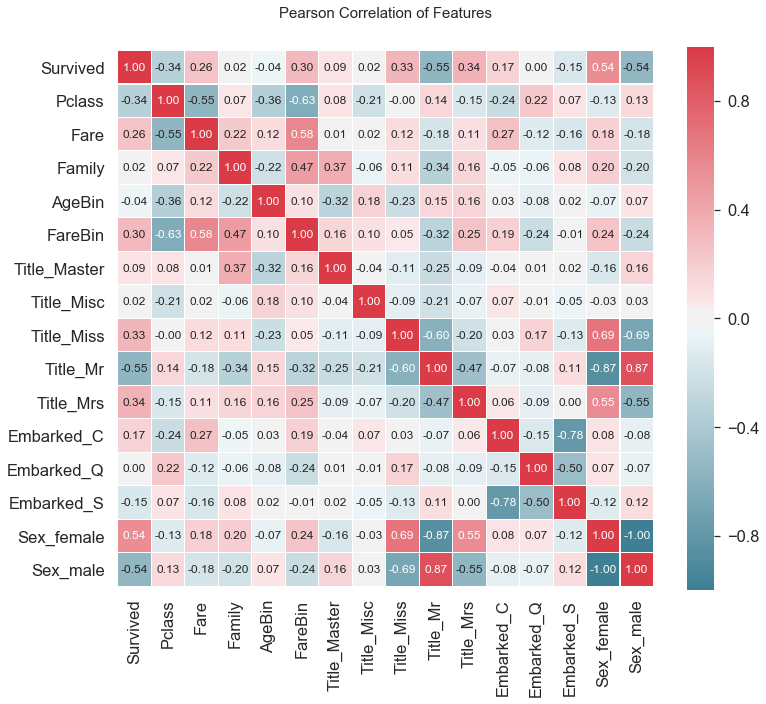

```python
sns.set(font_scale=1.5)
colormap = sns.diverging_palette(220, 10, as_cmap = True)
plt.figure(figsize=(12,10))
plt.title('Pearson Correlation of Features', y=1.05, size=15)
sns.heatmap(df_train.corr(), linewidths=0.1, vmax=1.0, square=True, cmap=colormap, linecolor = 'white', annot=True, annot_kws={'size':12}, fmt='.2f')
```

```python
df_train.info()
```

```
<class 'pandas.core.frame.DataFrame'>
RangeIndex: 891 entries, 0 to 890
Data columns (total 16 columns):
Survived        891 non-null int64
Pclass          891 non-null int64
Fare            891 non-null float64
Family          891 non-null int64
AgeBin          891 non-null int64
FareBin         891 non-null int64
Title_Master    891 non-null uint8
Title_Misc      891 non-null uint8
Title_Miss      891 non-null uint8
Title_Mr        891 non-null uint8
Title_Mrs       891 non-null uint8
Embarked_C      891 non-null uint8
Embarked_Q      891 non-null uint8
Embarked_S      891 non-null uint8
Sex_female      891 non-null uint8
Sex_male        891 non-null uint8
dtypes: float64(1), int64(5), uint8(10)
memory usage: 50.5 KB
```

```python
df_test.info()
```

```
<class 'pandas.core.frame.DataFrame'>
RangeIndex: 418 entries, 0 to 417
Data columns (total 15 columns):
Pclass          418 non-null int64
Fare            418 non-null float64
Family          418 non-null int64
AgeBin          418 non-null int64
FareBin         418 non-null int64
Title_Master    418 non-null uint8
Title_Misc      418 non-null uint8
Title_Miss      418 non-null uint8
Title_Mr        418 non-null uint8
Title_Mrs       418 non-null uint8
Embarked_C      418 non-null uint8
Embarked_Q      418 non-null uint8
Embarked_S      418 non-null uint8
Sex_female      418 non-null uint8
Sex_male        418 non-null uint8
dtypes: float64(1), int64(4), uint8(10)
memory usage: 20.5 KB
```

## **Chapter 5 - Model Data**

이제 지금까지 지금까지 살펴보고, 가공한 데이터로 머신러닝 모델을 만들어보겠습니다.

### **Chapter 5 - 1 - Model Generation and Prediction and Evaluation**

```python
X_train_data = df_train.drop('Survived', axis=1).values
X_train_label = df_train['Survived'].values
X_test_data = df_test.values
```

```python
alg = XGBClassifier(
                     base_score=0.5,
                     booster='gbtree',
                     colsample_bylevel=1,
                     colsample_bytree=1,
                     gamma=0,
                     importance_type='gain',
                     learning_rate=0.1,
                     max_delta_step=0,
                     max_depth=3,
                     min_child_weight=1,
                     missing=None,
                     n_estimators=1000,
                     n_jobs=1,
                     nthread=None,
                     num_boost_round=1000,
                     objective='reg:linear',
                     random_state=0,
                     reg_alpha=0,
                     reg_lambda=1,
                     scale_pos_weight=1,
                     seed=None,
                     silent=True,
                     subsample=1,
                     verbose_eval=1000
                  )


pre_prediction = 0
xgb_prediction = 0
splits_cnt = 5
kf = KFold(n_splits=splits_cnt ,random_state=0 ,shuffle=True)
for fold_no,(train_index, test_index) in enumerate(kf.split(df_train)):

    train_data, test_data = X_train_data[train_index],  X_train_data[test_index]
    train_label, test_label = X_train_label[train_index], X_train_label[test_index]


    print('-'*50)
    print('fold_no : '+str(fold_no))
    print('-'*50)
    alg.fit(train_data, train_label
            , eval_metric = 'logloss'
            , eval_set = [(train_data,train_label),(test_data, test_label)]
            , verbose=100
            , early_stopping_rounds=100)
    print('\n'*2)

    pre_predictions = alg.predict(test_data)

    predictions = alg.predict(X_test_data)
    xgb_prediction += predictions

#pre_final = pre_prediction / splits_cnt
xgb_final = xgb_prediction / splits_cnt
xgb_final_2 = np.round(xgb_final).astype(int)
```

```
--------------------------------------------------
fold_no : 0
--------------------------------------------------
Multiple eval metrics have been passed: 'validation_1-logloss' will be used for early stopping.

Will train until validation_1-logloss hasn't improved in 100 rounds.
Stopping. Best iteration:




--------------------------------------------------
fold_no : 1
--------------------------------------------------
Multiple eval metrics have been passed: 'validation_1-logloss' will be used for early stopping.

Will train until validation_1-logloss hasn't improved in 100 rounds.
Stopping. Best iteration:




--------------------------------------------------
fold_no : 2
--------------------------------------------------
Multiple eval metrics have been passed: 'validation_1-logloss' will be used for early stopping.

Will train until validation_1-logloss hasn't improved in 100 rounds.
Stopping. Best iteration:




--------------------------------------------------
fold_no : 3
--------------------------------------------------
Multiple eval metrics have been passed: 'validation_1-logloss' will be used for early stopping.

Will train until validation_1-logloss hasn't improved in 100 rounds.
Stopping. Best iteration:




--------------------------------------------------
fold_no : 4
--------------------------------------------------
Multiple eval metrics have been passed: 'validation_1-logloss' will be used for early stopping.

Will train until validation_1-logloss hasn't improved in 100 rounds.
Stopping. Best iteration:
```

```
Text(0,0.5,'Feature')
```

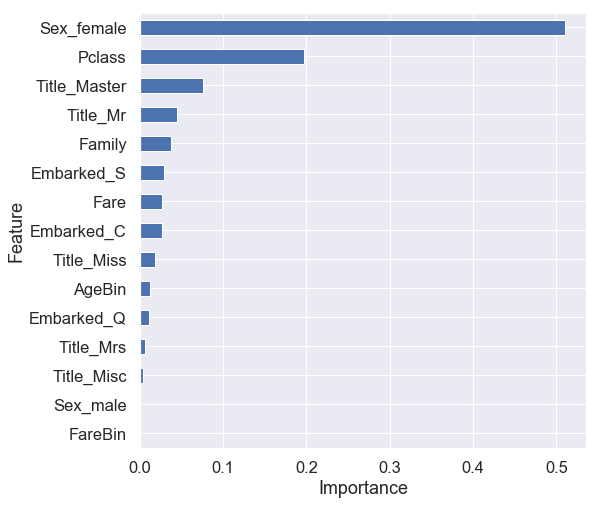

```python
feature_importance = alg.feature_importances_
Series_feat_imp = Series(feature_importance, index=df_test.columns)

plt.figure(figsize = (8,8))
Series_feat_imp.sort_values(ascending=True).plot.barh()
plt.xlabel('Importance')
plt.ylabel('Feature')
```

```
Confusion matrix, without normalization
[[93  4]
 [27 54]]
Normalized confusion matrix
[[0.96 0.04]
 [0.33 0.67]]
```

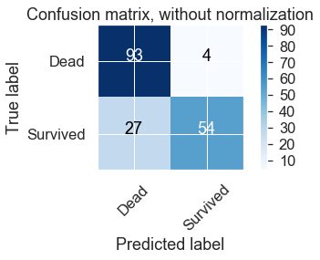

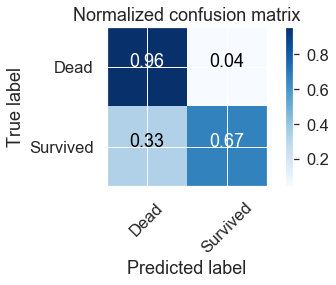

```python
#Plot Accuracy Summary
#Credit: http://scikit-learn.org/stable/auto_examples/model_selection/plot_confusion_matrix.html
import itertools
def plot_confusion_matrix(cm,
                          classes,
                          normalize=False,
                          title='Confusion matrix',
                          cmap=plt.cm.Blues):
    """
    This function prints and plots the confusion matrix.
    Normalization can be applied by setting `normalize=True`.
    """
    if normalize:
        cm = cm.astype('float') / cm.sum(axis=1)[:, np.newaxis]
        print("Normalized confusion matrix")
    else:
        print('Confusion matrix, without normalization')

    print(cm)

    plt.imshow(cm, interpolation='nearest', cmap=cmap)
    plt.title(title)
    plt.colorbar()
    tick_marks = np.arange(len(classes))
    plt.xticks(tick_marks, classes, rotation=45)
    plt.yticks(tick_marks, classes)

    fmt = '.2f' if normalize else 'd'
    thresh = cm.max() / 2.
    for i, j in itertools.product(range(cm.shape[0]), range(cm.shape[1])):
        plt.text(j, i, format(cm[i, j], fmt),
                 horizontalalignment="center",
                 color="white" if cm[i, j] > thresh else "black")

    plt.tight_layout()
    plt.ylabel('True label')
    plt.xlabel('Predicted label')

# Compute confusion matrix
cnf_matrix =  metrics.confusion_matrix(test_label, pre_predictions)
np.set_printoptions(precision=2)

class_names = ['Dead', 'Survived']
# Plot non-normalized confusion matrix


plt.figure(figsize=(6,4))
plot_confusion_matrix(cnf_matrix, classes=class_names,
                      title='Confusion matrix, without normalization')
# Plot normalized confusion matrix
plt.figure(figsize=(6,4))
plot_confusion_matrix(cnf_matrix, classes=class_names, normalize=True,
                      title='Normalized confusion matrix')
```

5번째 fold의 훈련데이터에 의한 f-1스코어는 약 85% 정도로 꽤 괜찮은 결과값을 보인다고 생각됩니다.  
2 *(93/(93+27))* (93/(93+4)) / ((93/(93+27)) + (93/(93+4)))

## **Chapter 6 - Submission**

```python
from IPython.display import Image
from IPython.core.display import HTML
```

[figure not shown]

```python
PATH = "C:/Users/hongo/OneDrive/BIGDATA/kaggle/titanic/"
Image(filename = PATH + "result.png")
```

실제 Submission 결과입니다.  
80%가 넘는 확률로 생존자를 예측 해냈다는 것을 알 수 있습니다.

- 본 결과는 kaggle의 Public leaderboard score로, 총 mission 데이터의 50%만 집계하여 스코어링 합니다.